# DM_2

数据挖掘互评作业二: 频繁模式与关联规则挖掘 代码仓库：https://github.com/L0FX/DM-HW2

```python
import csv
import pandas as pd
import numpy as np
import matplotlib.pyplot as plt

path = '/content/data/MyDrive/data/DM-2/'
```

1.数据集“Amazon product co-purchasing network”的分析研究

（https://snap.stanford.edu/data/amazon0302.html）

（1）数据获取与预处理

```python
# 将txt文件转为csv文件
with open(path+'amazon-meta.txt', 'r', encoding='utf-8') as F:
  content=F.readlines()
content=[x.strip()for x in content]

file= open(path+'amazon_clean_meta.txt','w',encoding='utf-8')
all_row=['Id','title','group','salesrank','categories','totalreviews','avgrating'] # Column names

for line in content:
  lines = line.split(':')
  if lines[0]=='Id':
    if (len(all_row)==7):
      for comp in all_row[0:6]:
        file.write(comp)
        file.write(',')

      file.write(all_row[6])
      file.write('\n')
      all_row=[]
      all_row.append(lines[1].strip())
  if lines[0]=='title':
    title=':'.join(lines[1:]).strip().replace(',',' ').replace('\n',' ').strip()
    all_row.append(title)
  if lines[0]=='group':
    all_row.append(lines[1].strip())
  if lines[0]=='salesrank':
    all_row.append(lines[1].strip())
  if lines[0]=='categories':
    all_row.append(lines[1].strip())
  if lines[0]=='reviews' and lines[1].strip()=='total':
    all_row.append(lines[2].split(' ')[1])
    all_row.append(lines[4].strip())

file.close()

meta = pd.read_csv(path+'amazon_clean_meta.txt',sep=',')
meta['Id'].iloc[0] = 1
meta.to_csv(path+'amazon_meta.csv',index=False)
```

```python
#数据简要展示
df = pd.read_csv(path+'amazon_meta.csv')
print(df.head(5))
print(df.dtypes)
```

[output not shown]

此处,Id为产品编号；title为产品名字；group为产品种类，包括Book、DVD、Video、Music或其他；salesrank为商品在Amazon的销售排名；categories为产品所属的产品类别层次结构中的位置；totalreviews为产品被购买数；avgrating为产品评价评分。

```python
#检查数据缺失值,发现无缺失值
print(df.isnull().any())
#删去重复数据
print(f'原始数据长度：{len(df)}')
df_nodup = df.drop_duplicates()
print(f'去重后数据长度：{len(df_nodup)}')
```

```
Unnamed: 0      False
Id              False
title           False
group           False
salesrank       False
categories      False
totalreviews    False
avgrating       False
dtype: bool
原始数据长度：349911
去重后数据长度：349911
```

对数据进行一系列探索性分析：

```python
numeric = ['salesrank','categories','totalreviews','avgrating']
print(df[numeric].describe().loc[['max', '75%', '50%', '25%', 'min']])
```

```
     salesrank  categories  totalreviews  avgrating
max  3796990.0       116.0        5545.0        5.0
75%   683980.5         6.0           7.0        5.0
50%   306787.0         3.0           2.0        4.0
25%    93928.0         2.0           0.0        0.0
min       -1.0         0.0           0.0        0.0
```

```python
def hist_plot(data, feature_list):
  for col in feature_list:
    data[col].hist(bins=8,histtype="bar",alpha=0.5)
    plt.title(f'Distribution of {col}')
    plt.show()
```

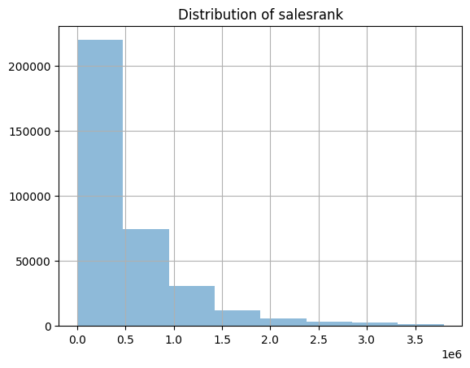

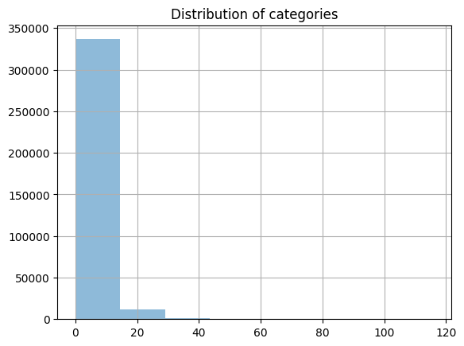

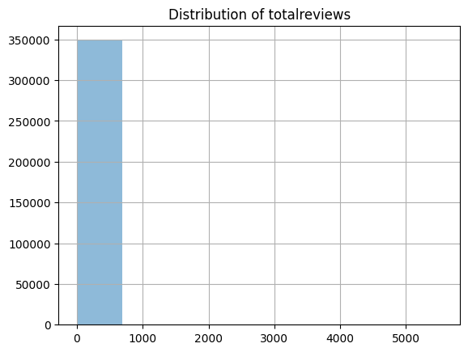

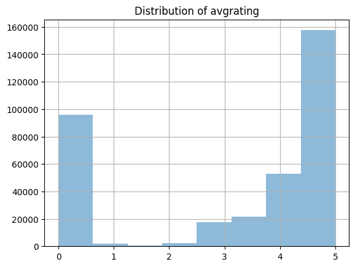

```python
hist_plot(df,numeric)
```

```python
def bar_plot(data, feature_list):
  for col in feature_list:
    print(data[col].value_counts())
    v = list(data[col].value_counts().values)
    id = list(data[col].value_counts().index)

    bar = plt.barh(id[:20],v[:20])
    plt.yticks(rotation = 45, size = 7)
    plt.xticks(rotation = 45, size = 7)
    plt.bar_label(bar, v[:20])
    plt.show()
```

```
title
Live                              73
Best of                           60
Super Hits                        57
Anthology                         57
Ultimate Collection               50
                                  ..
Plays Nino Rota                    1
Taking of Pelham One Two Three     1
Party Time  Vol. 5                 1
Divided by a Common Language       1
The Divine Comedy : Paradise       1
Name: count, Length: 329930, dtype: int64
```

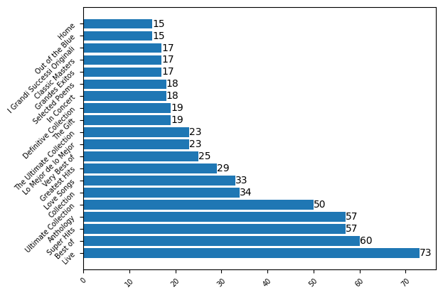

```
group
Book            255322
Music            66183
Video            16910
DVD              11481
Toy                  6
CE                   4
Software             2
Video Games          1
Baby Product         1
Sports               1
Name: count, dtype: int64
```

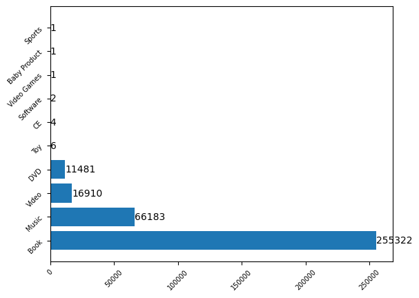

```python
bar_plot(df,['title','group'])
```

为方便后续挖掘关联规则，将数值型属性根据数值划分范围：

```python
def trans_avgrating(row):
  new = []
  if 0 <= row['avgrating'] < 1:
    new.append('[0,1)')
  elif 1 <= row['avgrating'] < 2:
    new.append('[1,2)')
  elif 2 <= row['avgrating'] < 3:
    new.append('[2,3)')
  elif 3 <= row['avgrating'] < 4:
    new.append('[3,4)')
  elif 4 <= row['avgrating']:
    new.append('[4,5]')
  return new
```

```python
def trans_reviews(row):
  new = []
  if 0 <= row['totalreviews'] < 5:
    new.append('[0,5)')
  elif 5 <= row['totalreviews'] < 10:
    new.append('[5,10)')
  elif 10 <= row['totalreviews'] < 1000:
    new.append('[10,1000)')
  elif 1000 <= row['totalreviews'] < 3000:
    new.append('[1000,3000)')
  elif 3000 <= row['totalreviews']:
    new.append('[3000,-)')
  return new
```

```python
def trans_categories(row):
  new = []
  if 0 <= row['categories'] < 2:
    new.append('[0,2)')
  elif 2 <= row['categories'] < 5:
    new.append('[2,5)')
  elif 5 <= row['categories'] < 10:
    new.append('[5,10)')
  elif 10 <= row['categories'] < 50:
    new.append('[10,50)')
  elif 50 <= row['categories']:
    new.append('[50,-)')
  return new
```

```python
def trans_salesrank(row):
  new = []
  if row['salesrank'] < 500000:
    new.append('[-,500000)')
  elif 500000 <= row['salesrank'] < 1000000:
    new.append('[500000,1000000)')
  elif 1000000 <= row['salesrank'] < 1500000:
    new.append('[1000000,1500000)')
  elif 1500000 <= row['salesrank'] < 2000000:
    new.append('[1500000,2000000)')
  elif 2000000 <= row['salesrank']:
    new.append('[2000000,-)')
  return new
```

```python
new_rating = []
new_reviews = []
new_rank = []
new_cat = []
for _, row in df.iterrows():
  new_rating.extend(trans_avgrating(row))
  new_reviews.extend(trans_reviews(row))
  new_rank.extend(trans_salesrank(row))
  new_cat.extend(trans_categories(row))
df['avgrating'] = new_rating
df['totalreviews'] = new_reviews
df['categories'] = new_cat
df['salesrank'] = new_rank
df.head(5)
```

|  | Unnamed: 0 | Id | title | group | salesrank | categories | totalreviews | avgrating |
| --- | --- | --- | --- | --- | --- | --- | --- | --- |
| 0 | 0 | 1 | Patterns of Preaching: A Sermon Sampler | Book | [-,500000) | [2,5) | [0,5) | [4,5] |
| 1 | 1 | 2 | Candlemas: Feast of Flames | Book | [-,500000) | [2,5) | [10,1000) | [4,5] |
| 2 | 2 | 3 | World War II Allied Fighter Planes Trading Cards | Book | [1000000,1500000) | [0,2) | [0,5) | [4,5] |
| 3 | 3 | 4 | Life Application Bible Commentary: 1 and 2 Tim... | Book | [500000,1000000) | [5,10) | [0,5) | [4,5] |
| 4 | 4 | 5 | Prayers That Avail Much for Business: Executive | Book | [-,500000) | [2,5) | [0,5) | [0,1) |

为进行后续的频繁模式挖掘，现将数据中的group，salesrank，categories，totalreviews，avgrating提取出来为子数据集并转化为list

```python
data = df[['avgrating','totalreviews','categories','salesrank','group']]
print(data.head(5))
arr = np.array(data)
d = arr.tolist()
```

```
  avgrating totalreviews categories          salesrank group
0     [4,5]        [0,5)      [2,5)         [-,500000)  Book
1     [4,5]    [10,1000)      [2,5)         [-,500000)  Book
2     [4,5]        [0,5)      [0,2)  [1000000,1500000)  Book
3     [4,5]        [0,5)     [5,10)   [500000,1000000)  Book
4     [0,1)        [0,5)      [2,5)         [-,500000)  Book
```

(2)频繁模式挖掘

使用Apriori算法或FP-Growth算法，根据处理后的数据集计算频繁项集和关联规则。关联规则挖掘是一种常用的数据挖掘技术，可以从数据集中发现项集之间的关联关系。

```python
!pip install apyori
from apyori import apriori
```

```
  Preparing metadata (setup.py) ... done
```

```python
result = list(apriori(transactions=d, min_support=0.1, min_confidence = 0.5))
```

```python
def show_result(result):
  lastItems = []
  for i in result:
    tempItem = ';'.join(i.items)
    sup = round(i.support,4)
    for j in i.ordered_statistics:
      col = []
      tempItemBase = ';'.join(j.items_base)
      tempItemAdd = ';'.join(j.items_add)
      col.append(tempItem)
      col.append(sup)
      col.append(tempItemBase)
      col.append(tempItemAdd)
      col.append(round(j.confidence,4))
      col.append(round(j.lift,2))
      lastItems.append(col)
  lastItems = pd.DataFrame(lastItems)
  lastItems.columns=['LastItem','Support','ItemBase','ItemAdd','Confidence','Lift']
  lastItems.index = range(len(lastItems))
  print(len(lastItems))
  lastItems = lastItems.sort_values('Confidence',ascending = False).reset_index()
  print(lastItems.head(10))

  return lastItems
```

```python
lastItems = show_result(result)
```

```
128
   index                     LastItem  Support                ItemBase  \
0     86       [0,1);[-,500000);[0,5)   0.1064        [0,1);[-,500000)
1    119       [2,5);[0,1);Book;[0,5)   0.1100        [2,5);[0,1);Book
2     54             [0,1);Book;[0,5)   0.2260              [0,1);Book
3    101            [2,5);[0,1);[0,5)   0.1271             [2,5);[0,1)
4     29                  [0,1);[0,5)   0.2738                   [0,1)
5     85       Music;[-,500000);[4,5]   0.1350             Music;[4,5]
6     79  [500000,1000000);Book;[4,5]   0.1068  [500000,1000000);[4,5]
7     74  [2,5);[500000,1000000);Book   0.1138  [2,5);[500000,1000000)
8     18        [500000,1000000);Book   0.2037        [500000,1000000)
9     19             Music;[-,500000)   0.1835                   Music

      ItemAdd  Confidence  Lift
0       [0,5)      1.0000  1.54
1       [0,5)      1.0000  1.54
2       [0,5)      1.0000  1.54
3       [0,5)      1.0000  1.54
4       [0,5)      1.0000  1.54
5  [-,500000)      0.9888  1.53
6        Book      0.9859  1.35
7        Book      0.9803  1.34
8        Book      0.9730  1.33
9  [-,500000)      0.9701  1.50
```

（3）模式命名与分析

分析：根据上面的输出结果，以index为19的数据为例，存在“Music->[-,500000)”，即“音乐类别的产品->销售排名高于500000”，可以得出，音乐类别的产品的销售排名有约97%的概率高于500000，且这种情况的发生比例约为18.35%。其余数据同理可进行解释。

模式命名：关于产品的类别与评分、销售排名、被购买次数的关系，我们可以将其命名为产品推销模式。

（4）可视化

[figure not shown]

```python
## 绘制支持度和置信度的散点图
def scatter(items,size):
  items.plot(kind="scatter",x = "Support",c = "r",
            y = "Confidence",s = size,figsize=(8,5))
  plt.grid("on")
  plt.xlabel("Support",size = 12)
  plt.ylabel("Confidence",size = 12)
  plt.title(f"Scatter plot of {size} rules")
  plt.show()
```

```python
import networkx as nx
```

```python
def network(items,size):
  plt.figure(figsize=(8,8))
  ## 生成社交网络图
  G=nx.DiGraph()

  draw_df = items[0:size]

  ## 为图像添加边
  for ii in draw_df.index:
    G.add_edge(draw_df.ItemBase[ii],draw_df.ItemAdd[ii],weight = draw_df.Confidence[ii])

  ## 定义2种边
  elarge=[(u,v) for (u,v,d) in G.edges(data=True) if d['weight'] >0.6]
  emidle=[(u,v) for (u,v,d) in G.edges(data=True) if (d['weight'] <= 0.6)&(d['weight'] >= 0.45)]
  esmall=[(u,v) for (u,v,d) in G.edges(data=True) if d['weight'] <= 0.45]

  ## 图的布局方式
  pos=nx.circular_layout(G)

  # 根据规则的置信度节点的大小
  nx.draw_networkx_nodes(G,pos,alpha=0.4)

  # 设置边的形式
  nx.draw_networkx_edges(G,pos,edgelist=elarge,
                      width=2,alpha=0.6,edge_color='r')
  nx.draw_networkx_edges(G,pos,edgelist=emidle,
                      width=2,alpha=0.6,edge_color='g',style='dashdot')
  nx.draw_networkx_edges(G,pos,edgelist=esmall,
                      width=2,alpha=0.6,edge_color='b',style='dashed')

  # 为节点添加标签
  nx.draw_networkx_labels(G,pos,font_size=10)

  plt.axis('off')
  plt.title(f"Sample network of {size} rules")
  plt.show()
```

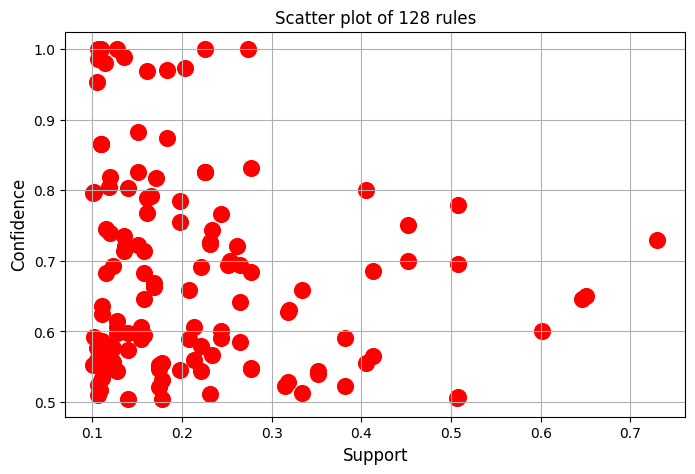

```python
scatter(lastItems,128)
```

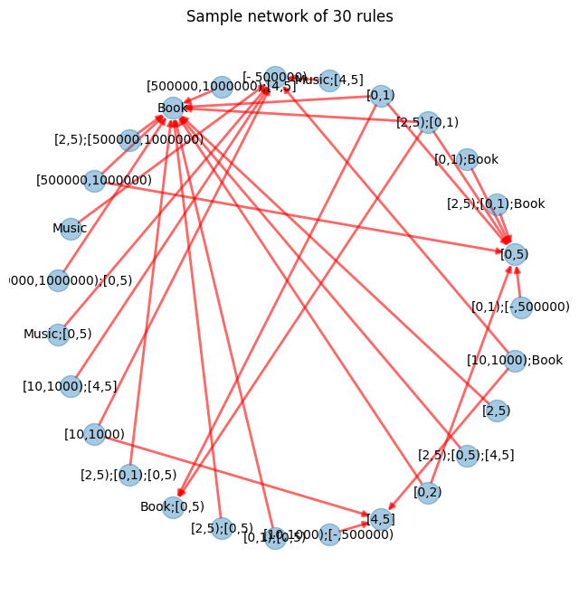

```python
network(lastItems,30)
```

2.数据集“MOOC User Action Dataset”的分析研究

（https://snap.stanford.edu/data/act-mooc.html）

（1）数据获取与预处理

```python
actions = pd.read_csv(path+'mooc_actions.tsv',sep='\t')
features = pd.read_csv(path+'mooc_action_features.tsv',sep='\t')
labels = pd.read_csv(path+'mooc_action_labels.tsv',sep='\t')
print(actions.head(10))
print(features.head(10))
print(labels.head(10))
```

```
   ACTIONID  USERID  TARGETID  TIMESTAMP
0         0       0         0        0.0
1         1       0         1        6.0
2         2       0         2       41.0
3         3       0         1       49.0
4         4       0         2       51.0
5         5       0         3       55.0
6         6       0         4       59.0
7         7       0         5       62.0
8         8       0         6       65.0
9         9       0         7      113.0
   ACTIONID  FEATURE0  FEATURE1  FEATURE2   FEATURE3
0         0 -0.319991 -0.435701  0.106784  -0.067309
1         1 -0.319991 -0.435701  0.106784  -0.067309
2         2 -0.319991 -0.435701  0.106784  -0.067309
```

[output cut: 18 more lines]

此处变量的意义为：

ACTIONID:每个操作的唯一id。

USERID:每个用户的唯一id。

TARGETID:每个目标活动的唯一id。

TIMESTAMP:动作的时间戳，以秒为单位。

FEATUREx:与动作相关联的特征值。总共四个，使其成为一个四维特征向量。

LABEL:一个二进制标签，指示学生在操作后是否退出。退出操作的值为1，否则为0。

```python
# 将三个表合并
act = pd.merge(actions,features,on='ACTIONID')
act = pd.merge(act,labels,on='ACTIONID')
print(act.head())
print(act.dtypes)
```

```
   ACTIONID  USERID  TARGETID  TIMESTAMP  FEATURE0  FEATURE1  FEATURE2  \
0         0       0         0        0.0 -0.319991 -0.435701  0.106784
1         1       0         1        6.0 -0.319991 -0.435701  0.106784
2         2       0         2       41.0 -0.319991 -0.435701  0.106784
3         3       0         1       49.0 -0.319991 -0.435701  0.106784
4         4       0         2       51.0 -0.319991 -0.435701  0.106784

   FEATURE3  LABEL
0 -0.067309      0
1 -0.067309      0
2 -0.067309      0
3 -0.067309      0
4 -0.067309      0
ACTIONID       int64
USERID         int64
TARGETID       int64
TIMESTAMP    float64
FEATURE0     float64
FEATURE1     float64
FEATURE2     float64
FEATURE3     float64
LABEL          int64
dtype: object
```

```python
# 展示数据情况
for col in ['ACTIONID','USERID','TARGETID','LABEL']:
  print(act[col].value_counts())
```

```
ACTIONID
175190    4
147954    4
194071    4
186018    4
385085    4
         ..
390664    1
390665    1
390666    1
390667    1
411748    1
Name: count, Length: 396633, dtype: Int64
USERID
1181    505
```

[output cut: 28 more lines]

```python
print(act[['TIMESTAMP','FEATURE0','FEATURE1','FEATURE2','FEATURE3']].describe().loc[['max', '75%', '50%', '25%', 'min']])
```

```
     TIMESTAMP   FEATURE0   FEATURE1    FEATURE2    FEATURE3
max  2572086.0  57.647547  98.796794  276.169444  183.970924
75%  2011689.0  -0.319991  -0.435701    0.106784   -0.067309
50%  1458102.0  -0.319991  -0.435701    0.106784   -0.067309
25%   784636.0  -0.319991  -0.435701   -0.394237   -0.067309
min        0.0  -0.319991  -0.435701   -0.394237   -0.067309
```

将TIMESTAMP,ACTIONID,TARGETID,FEATUREx,LABEL转化为适合用于频繁项集与关联规则挖掘的格式

```python
# 将TIMESTAMP特征根据数值划分范围
def trans_timestamp(row):
  new = []
  if row['TIMESTAMP'] < 700000:
    new.append('[-,500000)')
  elif 500000 <= row['TIMESTAMP'] < 1000000:
    new.append('[500000,1000000)')
  elif 1000000 <= row['TIMESTAMP'] < 1500000:
    new.append('[1000000,1500000)')
  elif 1500000 <= row['TIMESTAMP'] < 2000000:
    new.append('[1500000,2000000)')
  elif 2000000 <= row['TIMESTAMP']:
    new.append('[2000000,-)')
  return new
new = []
for _,row in act.iterrows():
  trans = trans_timestamp(row)
  new.extend(trans)
act['TIMESTAMP'] = new
```

```python
# 将属性值转化为字符串
act['ACTIONID'] = act['ACTIONID'].astype('string')
act['TARGETID'] = act['TARGETID'].astype('string')
act['LABEL'] = act['LABEL'].astype('string')
act['FEATURE0'] = act['FEATURE0'].astype('string')
act['FEATURE1'] = act['FEATURE1'].astype('string')
act['FEATURE2'] = act['FEATURE2'].astype('string')
act['FEATURE3'] = act['FEATURE3'].astype('string')
act['USERID'] = act['USERID'].astype('string')
print(act.dtypes)
```

[output not shown]

```python
# 将FEATURE0,FEATURE1,FEATURE2,FEATURE3合并
act['FEATURES'] = act['FEATURE0'] + ',' + act['FEATURE1'] + ',' + act['FEATURE2'] + ',' + act['FEATURE3']
```

```python
act['new_TARGETID'] = 'TARGETID_' + act['TARGETID']
act['new_ACTIONID'] = 'ACTIONID_' + act['ACTIONID']
act['new_LABEL'] = 'LABEL_' + act['LABEL']
```

```python
print(act.head())
```

```
  ACTIONID  USERID TARGETID   TIMESTAMP             FEATURE0  \
0        0       0        0  [-,500000)  -0.3199914794575269
1        1       0        1  [-,500000)  -0.3199914794575269
2        2       0        2  [-,500000)  -0.3199914794575269
3        3       0        1  [-,500000)  -0.3199914794575269
4        4       0        2  [-,500000)  -0.3199914794575269

              FEATURE1          FEATURE2             FEATURE3 LABEL  \
0  -0.4357014334929225  0.10678377884769  -0.0673092397645177     0
1  -0.4357014334929225  0.10678377884769  -0.0673092397645177     0
2  -0.4357014334929225  0.10678377884769  -0.0673092397645177     0
3  -0.4357014334929225  0.10678377884769  -0.0673092397645177     0
4  -0.4357014334929225  0.10678377884769  -0.0673092397645177     0

                                            FEATURES new_TARGETID  \
0  -0.3199914794575269,-0.4357014334929225,0.1067...   TARGETID_0
1  -0.3199914794575269,-0.4357014334929225,0.1067...   TARGETID_1
2  -0.3199914794575269,-0.4357014334929225,0.1067...   TARGETID_2
3  -0.3199914794575269,-0.4357014334929225,0.1067...   TARGETID_1
4  -0.3199914794575269,-0.4357014334929225,0.1067...   TARGETID_2

  new_ACTIONID new_LABEL
0   ACTIONID_0   LABEL_0
1   ACTIONID_1   LABEL_0
2   ACTIONID_2   LABEL_0
3   ACTIONID_3   LABEL_0
4   ACTIONID_4   LABEL_0
```

为方便后续频繁项集与关联规则挖掘，在经过初步实验后，发现LABEL属性值的分布有着巨大差异，所以将原数据集根据LABEL属性的值（0或1）划分为两个数据集，不干扰后续分析

```python
labels_group = act.groupby('new_LABEL')
group_0 = labels_group.get_group('LABEL_0')
group_0
```

|  | ACTIONID | USERID | TARGETID | TIMESTAMP | FEATURE0 | FEATURE1 | FEATURE2 | FEATURE3 | LABEL | FEATURES | new_TARGETID | new_ACTIONID | new_LABEL |
| --- | --- | --- | --- | --- | --- | --- | --- | --- | --- | --- | --- | --- | --- |
| 0 | 0 | 0 | 0 | [-,500000) | -0.3199914794575269 | -0.4357014334929225 | 0.10678377884769 | -0.0673092397645177 | 0 | -0.3199914794575269,-0.4357014334929225,0.1067... | TARGETID_0 | ACTIONID_0 | LABEL_0 |
| 1 | 1 | 0 | 1 | [-,500000) | -0.3199914794575269 | -0.4357014334929225 | 0.10678377884769 | -0.0673092397645177 | 0 | -0.3199914794575269,-0.4357014334929225,0.1067... | TARGETID_1 | ACTIONID_1 | LABEL_0 |
| 2 | 2 | 0 | 2 | [-,500000) | -0.3199914794575269 | -0.4357014334929225 | 0.10678377884769 | -0.0673092397645177 | 0 | -0.3199914794575269,-0.4357014334929225,0.1067... | TARGETID_2 | ACTIONID_2 | LABEL_0 |
| 3 | 3 | 0 | 1 | [-,500000) | -0.3199914794575269 | -0.4357014334929225 | 0.10678377884769 | -0.0673092397645177 | 0 | -0.3199914794575269,-0.4357014334929225,0.1067... | TARGETID_1 | ACTIONID_3 | LABEL_0 |
| 4 | 4 | 0 | 2 | [-,500000) | -0.3199914794575269 | -0.4357014334929225 | 0.10678377884769 | -0.0673092397645177 | 0 | -0.3199914794575269,-0.4357014334929225,0.1067... | TARGETID_2 | ACTIONID_4 | LABEL_0 |
| ... | ... | ... | ... | ... | ... | ... | ... | ... | ... | ... | ... | ... | ... |
| 411744 | 411744 | 7026 | 8 | [2000000,-) | -0.3199914794575269 | -0.4357014334929225 | 0.10678377884769 | -0.0673092397645177 | 0 | -0.3199914794575269,-0.4357014334929225,0.1067... | TARGETID_8 | ACTIONID_411744 | LABEL_0 |
| 411745 | 411745 | 6842 | 8 | [2000000,-) | -0.3199914794575269 | -0.4357014334929225 | 0.10678377884769 | -0.0673092397645177 | 0 | -0.3199914794575269,-0.4357014334929225,0.1067... | TARGETID_8 | ACTIONID_411745 | LABEL_0 |
| 411746 | 411746 | 7026 | 9 | [2000000,-) | -0.3199914794575269 | -0.4357014334929225 | 0.10678377884769 | -0.0673092397645177 | 0 | -0.3199914794575269,-0.4357014334929225,0.1067... | TARGETID_9 | ACTIONID_411746 | LABEL_0 |
| 411747 | 411747 | 6842 | 5 | [2000000,-) | -0.3199914794575269 | -0.4357014334929225 | 0.10678377884769 | -0.0673092397645177 | 0 | -0.3199914794575269,-0.4357014334929225,0.1067... | TARGETID_5 | ACTIONID_411747 | LABEL_0 |
| 411748 | 411748 | 70 | 23 | [2000000,-) | -0.3199914794575269 | -0.4357014334929225 | 0.10678377884769 | -0.0673092397645177 | 0 | -0.3199914794575269,-0.4357014334929225,0.1067... | TARGETID_23 | ACTIONID_411748 | LABEL_0 |

407683 rows × 13 columns

```python
group_1 = labels_group.get_group('LABEL_1')
group_1
```

|  | ACTIONID | USERID | TARGETID | TIMESTAMP | FEATURE0 | FEATURE1 | FEATURE2 | FEATURE3 | LABEL | FEATURES | new_TARGETID | new_ACTIONID | new_LABEL |
| --- | --- | --- | --- | --- | --- | --- | --- | --- | --- | --- | --- | --- | --- |
| 135 | 135 | 4 | 16 | [-,500000) | -0.3199914794575269 | 2.1087215250683182 | -0.3942373836437072 | -0.0673092397645177 | 1 | -0.3199914794575269,2.1087215250683182,-0.3942... | TARGETID_16 | ACTIONID_135 | LABEL_1 |
| 307 | 307 | 42 | 14 | [-,500000) | 1.0280908205665915 | -0.4357014334929225 | -0.3942373836437072 | -0.0673092397645177 | 1 | 1.0280908205665915,-0.4357014334929225,-0.3942... | TARGETID_14 | ACTIONID_307 | LABEL_1 |
| 381 | 381 | 46 | 5 | [-,500000) | -0.3199914794575269 | -0.4357014334929225 | 0.10678377884769 | -0.0673092397645177 | 1 | -0.3199914794575269,-0.4357014334929225,0.1067... | TARGETID_5 | ACTIONID_381 | LABEL_1 |
| 459 | 459 | 68 | 9 | [-,500000) | -0.3199914794575269 | -0.4357014334929225 | 2.611889591304676 | 5.351482786005339 | 1 | -0.3199914794575269,-0.4357014334929225,2.6118... | TARGETID_9 | ACTIONID_459 | LABEL_1 |
| 626 | 626 | 87 | 13 | [-,500000) | -0.3199914794575269 | 2.1087215250683182 | -0.3942373836437072 | -0.0673092397645177 | 1 | -0.3199914794575269,2.1087215250683182,-0.3942... | TARGETID_13 | ACTIONID_626 | LABEL_1 |
| ... | ... | ... | ... | ... | ... | ... | ... | ... | ... | ... | ... | ... | ... |
| 411457 | 411457 | 7045 | 16 | [2000000,-) | -0.3199914794575269 | 2.1087215250683182 | -0.3942373836437072 | -0.0673092397645177 | 1 | -0.3199914794575269,2.1087215250683182,-0.3942... | TARGETID_16 | ACTIONID_411457 | LABEL_1 |
| 411658 | 411658 | 6863 | 25 | [2000000,-) | -0.3199914794575269 | -0.4357014334929225 | 0.6078049413390874 | 1.5382587678709956 | 1 | -0.3199914794575269,-0.4357014334929225,0.6078... | TARGETID_25 | ACTIONID_411658 | LABEL_1 |
| 411661 | 411661 | 7046 | 5 | [2000000,-) | -0.3199914794575269 | -0.4357014334929225 | 0.10678377884769 | -0.0673092397645177 | 1 | -0.3199914794575269,-0.4357014334929225,0.1067... | TARGETID_5 | ACTIONID_411661 | LABEL_1 |
| 411665 | 411665 | 31 | 96 | [2000000,-) | 2.37617312059071 | -0.4357014334929225 | -0.3942373836437072 | -0.0673092397645177 | 1 | 2.37617312059071,-0.4357014334929225,-0.394237... | TARGETID_96 | ACTIONID_411665 | LABEL_1 |
| 411710 | 411710 | 972 | 12 | [2000000,-) | -0.3199914794575269 | -0.4357014334929225 | 0.10678377884769 | -0.0673092397645177 | 1 | -0.3199914794575269,-0.4357014334929225,0.1067... | TARGETID_12 | ACTIONID_411710 | LABEL_1 |

4066 rows × 13 columns

将数据转化为用于频繁项集挖掘的格式

```python
g1 = group_1[['new_ACTIONID','new_TARGETID','TIMESTAMP']]
g0 = group_0[['new_ACTIONID','new_TARGETID','TIMESTAMP']]

arr1 = np.array(g1)
arr0 = np.array(g0)
d1 = arr1.tolist()
d0 = arr0.tolist()
```

（2）频繁模式挖掘

a.针对LABEL=1部分数据

```python
result1 = list(apriori(transactions=d1, min_support=0.01, min_confidence = 0.2))
```

```python
lastItems1 = show_result(result1)
```

```
9
   index                LastItem  Support     ItemBase      ItemAdd  \
0      8   [-,500000);TARGETID_9   0.0310   TARGETID_9   [-,500000)
1      2  TARGETID_13;[-,500000)   0.0413  TARGETID_13   [-,500000)
2      3  TARGETID_15;[-,500000)   0.0307  TARGETID_15   [-,500000)
3      7   TARGETID_8;[-,500000)   0.0234   TARGETID_8   [-,500000)
4      5  TARGETID_19;[-,500000)   0.0103  TARGETID_19   [-,500000)
5      6   TARGETID_7;[-,500000)   0.0111   TARGETID_7   [-,500000)
6      4  TARGETID_16;[-,500000)   0.0307  TARGETID_16   [-,500000)
7      1             [2000000,-)   0.2415               [2000000,-)
8      0              [-,500000)   0.2405                [-,500000)

   Confidence  Lift
0      0.5316  2.21
1      0.4667  1.94
2      0.4195  1.74
3      0.3893  1.62
4      0.3889  1.62
5      0.3689  1.53
6      0.3613  1.50
7      0.2415  1.00
8      0.2405  1.00
```

a.针对LABEL=0部分数据

```python
result0 = list(apriori(transactions=d0, min_support=0.01, min_confidence = 0.2))
```

```python
lastItems0 = show_result(result0)
```

```
15
   index                 LastItem  Support     ItemBase      ItemAdd  \
0     12  [2000000,-);TARGETID_79   0.0104  TARGETID_79  [2000000,-)
1      3    TARGETID_1;[-,500000)   0.0175   TARGETID_1   [-,500000)
2      4   TARGETID_13;[-,500000)   0.0114  TARGETID_13   [-,500000)
3      5   TARGETID_14;[-,500000)   0.0171  TARGETID_14   [-,500000)
4      8    TARGETID_3;[-,500000)   0.0177   TARGETID_3   [-,500000)
5     10    [-,500000);TARGETID_5   0.0134   TARGETID_5   [-,500000)
6     14    [-,500000);TARGETID_9   0.0170   TARGETID_9   [-,500000)
7      9    TARGETID_4;[-,500000)   0.0136   TARGETID_4   [-,500000)
8     11    TARGETID_7;[-,500000)   0.0174   TARGETID_7   [-,500000)
9     13    TARGETID_8;[-,500000)   0.0216   TARGETID_8   [-,500000)

   Confidence  Lift
0      0.8278  3.20
1      0.5540  2.60
2      0.5356  2.52
3      0.5202  2.44
4      0.5092  2.39
5      0.4913  2.31
6      0.4855  2.28
7      0.4799  2.25
8      0.4608  2.16
9      0.4594  2.16
```

（3）模式命名与分析

**分析：**

a.LABEL=1

a.LABEL=0

联系两种label的结果，可以发现，无论用户是否在操作后的退出，在时间点500000前，用户均有可观的概率目标网页为7,8,9和13。

**模式命名：**

根据上面的分析，我们可以得出不同时间点用户的需求不同，即存在“时间偏好”的关系模式。

（4）可视化

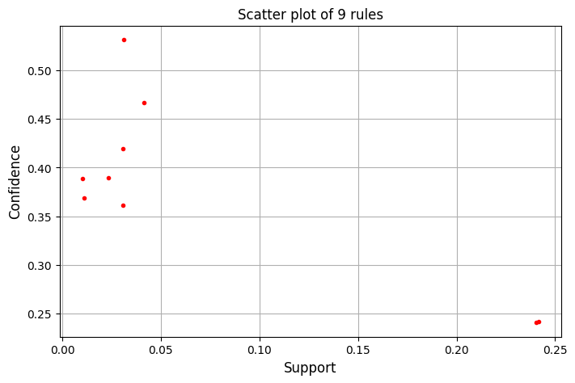

```python
# LABEL=1
# 绘制支持度和置信度的散点图
scatter(lastItems1,9)
```

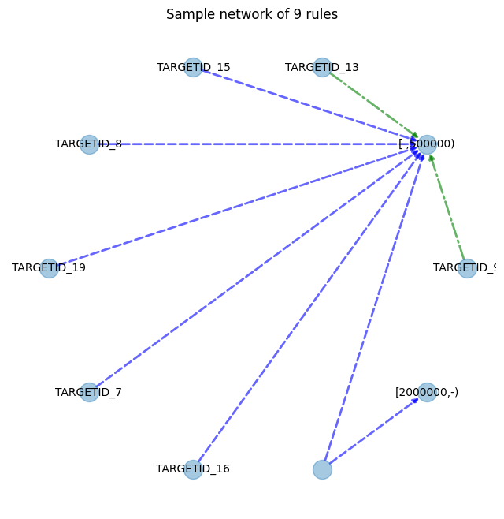

```python
network(lastItems1,9)
```

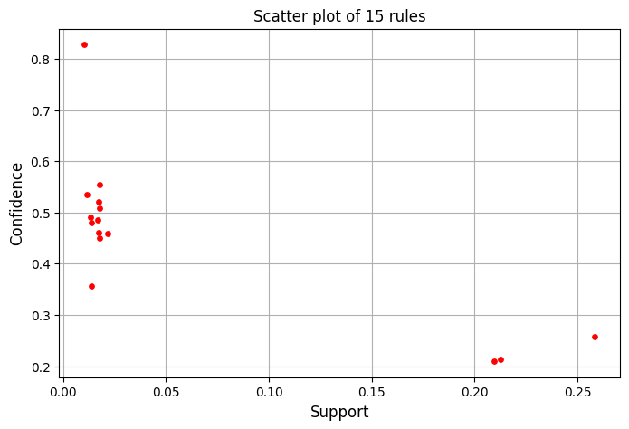

```python
# LABEL=0
scatter(lastItems0,15)
```

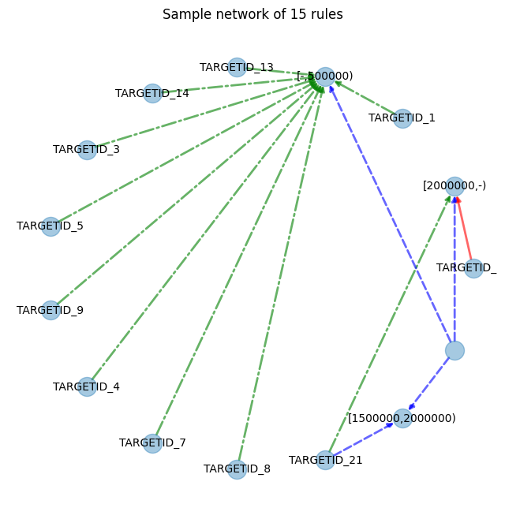

```python
network(lastItems0,15)
```